# Challenge 7: Incorporating Multiple Inputs

Functions + Fish

Author

```r
library(tidyverse)
library(here)
library(forcats)

fish_csv <- read_csv(here::here("data","BlackfootFish.csv"))
```

## Condition Index

**1. There are specific units required for the calculation of a condition index – length must be in centimeters and weight must be in grams. The weight data for the Blackfoot River fish were collected in grams; the length data were collected in millimeters. Transform the length data to the correct units.**

```r
fish <- fish_csv |>
  mutate(length = length / 10)
```

**2. Collecting data of this sort can be very messy! Write a function that will replace unlikely `length` and `weight` measurements with `NA`. Your function should accept at least three inputs:**

- **a vector of measurements,**
- **the minimum reasonable value,**
- **the maximum reasonable value.**

**If a value falls outside these bounds, you should replace it with an `NA`.**

**Tip**

If you are struggling with the structure of your function, I would suggest reading the [Mutating Function](https://r4ds.hadley.nz/functions.html#mutate-functions) from R4DS.

```r
set_bounds_on_data <- function(vector, min, max){
  if (!is.numeric(vector)) {
    stop("Error: The input vector must be numeric.")
  }
  if (!is.numeric(min) | !is.numeric(max)) {
    stop("Error: The input min and max must be numeric.")
  }
  if (length(vector) <= 1) {
    stop("Error: The input vector must have more than one element.")
  }

  return(ifelse(
    vector < min | vector > max,
    NA,
    vector
    ))
}
```

**3. After consulting the [Montana Record Table](https://fwp.mt.gov/fish/anglingData/records) for the four species of trout included in these data, I have conjectured that it is unlikely to have measurements for fish below 5 cm and above 80 cm in length or below 10 g and above 4,000 g in weight. Use your function to modify the `length` and `weight` columns of the `fish` dataset based on my cutoffs.**

```r
fish <- fish |>
  mutate(
    length = set_bounds_on_data(length, 5, 80),
    weight = set_bounds_on_data(weight, 10, 4000)
  )
```

**3. Write a function to calculate the condition index of a fish, given inputs of weight and length.**

**Warning**

Consider whether you will write a function that works with vectors (accepting vectors as inputs) or a function that works with data frames (accepting a dataset and variable names as inputs)!

```r
calculate_fish_index <- function(weight_vector, len_vector){
  if (!is.numeric(weight_vector) || !is.numeric(len_vector)) {
    stop("Error: Both weight and length inputs must be numeric vectors.")
  }
  if (length(weight_vector) != length(len_vector)) {
    stop("Error: The weight and length vectors must be of the same length.")
  }
  if (any(len_vector == 0, na.rm = TRUE)) {
    stop("Error: Length values must not be zero.")
  }

  condition_index <- weight_vector / (len_vector ^ 3)

  return(condition_index)
}
```

**4. Make a thoughtful visualization of how fish conditions have varied over the duration of this study.**

**To be thoughtful…**

… you need to use at least a third variable!

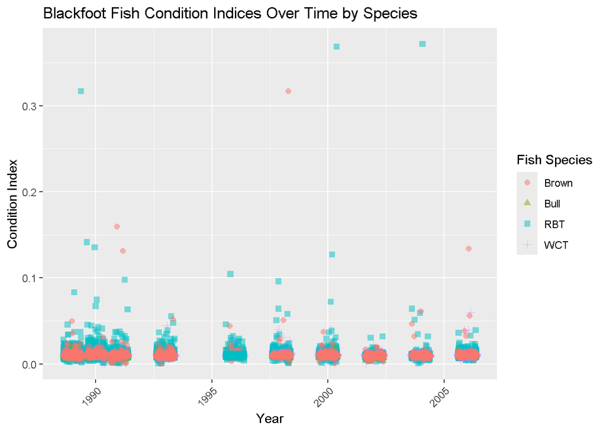

```r
fish |>
  mutate(
    condition_index = calculate_fish_index(weight, length)  # Calculate condition index
  ) |>
ggplot(mapping = aes(
  x = year,
  y = condition_index,
  color = species
  )) +
geom_jitter(aes(shape = species),
            size = 2,
            alpha = 0.5) +
labs(
  title = "Blackfoot Fish Condition Indices Over Time by Species",
  x = "Year",
  y = "Condition Index",
  color = "Fish Species",
  shape = "Fish Species"
) +
theme(
  axis.text.x = element_text(angle = 45, hjust = 1),
)
```